# Titanic Analysis 2.0

Index:

1- Data Exploration  
2- Data Wrangling  
3- Pre-Analysis  
3- Graphs  
4- Main Analysis  
5- Conclusion

```python
# Importing libararies and files

import pandas as pd
import numpy as np
import csv
import matplotlib.pyplot as plt
import seaborn as sns

file = 'titanic-data.csv'

data = pd.read_csv(file)
```

## Data Exploration

Here I will try to answer the following questions:

- What are the data type(s)?
- Is the data clean?
  - Is there duplicates?
  - Are the types of data correctly classified?
  - Is there dirty data that needs cleaning up?

```python
#What are the data type(s)?
print(data.info()) # There seems to be missing values in the age and cabin column




# Data Head and shape
print(data.head())

print(data.shape) # There are 891 rows and 12 columns
```

```
<class 'pandas.core.frame.DataFrame'>
RangeIndex: 891 entries, 0 to 890
Data columns (total 12 columns):
PassengerId    891 non-null int64
Survived       891 non-null int64
Pclass         891 non-null int64
Name           891 non-null object
Sex            891 non-null object
Age            714 non-null float64
SibSp          891 non-null int64
Parch          891 non-null int64
Ticket         891 non-null object
Fare           891 non-null float64
Cabin          204 non-null object
Embarked       889 non-null object
dtypes: float64(2), int64(5), object(5)
memory usage: 83.6+ KB
None
   PassengerId  Survived  Pclass  \
0            1         0       3
1            2         1       1
2            3         1       3
3            4         1       1
4            5         0       3

                                                Name     Sex   Age  SibSp  \
0                            Braund, Mr. Owen Harris    male  22.0      1
1  Cumings, Mrs. John Bradley (Florence Briggs Th...  female  38.0      1
2                             Heikkinen, Miss. Laina  female  26.0      0
3       Futrelle, Mrs. Jacques Heath (Lily May Peel)  female  35.0      1
4                           Allen, Mr. William Henry    male  35.0      0

   Parch            Ticket     Fare Cabin Embarked
0      0         A/5 21171   7.2500   NaN        S
1      0          PC 17599  71.2833   C85        C
2      0  STON/O2. 3101282   7.9250   NaN        S
3      0            113803  53.1000  C123        S
4      0            373450   8.0500   NaN        S
(891, 12)
```

## Data Wrangling

There are 177 rows missing in the age column. That is a lot of missing values. I will remove the missing values, since, if I impute them, it will have a bias in my analysis. Note: I should use this (dropped_age variable) only in age-related analyses I noticed that there is a lot of values missing in the Cabin column (687 values), and there is a few values missing in the embarked column.

```python
dropped_age = data.dropna(axis=0, subset=['Age'])
print(dropped_age.info())
```

```
<class 'pandas.core.frame.DataFrame'>
Int64Index: 714 entries, 0 to 890
Data columns (total 12 columns):
PassengerId    714 non-null int64
Survived       714 non-null int64
Pclass         714 non-null int64
Name           714 non-null object
Sex            714 non-null object
Age            714 non-null float64
SibSp          714 non-null int64
Parch          714 non-null int64
Ticket         714 non-null object
Fare           714 non-null float64
Cabin          185 non-null object
Embarked       712 non-null object
dtypes: float64(2), int64(5), object(5)
memory usage: 72.5+ KB
None
```

## Pre-Analysis

Initial Hypothesis: Groups that are more likely to survive:

- 16-35 Years old
- Males
- Upper Class

## Explaratory Graphs

```python
#groupbys
parch_group = data.groupby('Parch')['PassengerId'].count()
sib_group = data.groupby('SibSp')['PassengerId'].count()
pclass_group = data.groupby('Pclass')['PassengerId'].count()
survived_group = data.groupby('Survived')['PassengerId'].count()
```

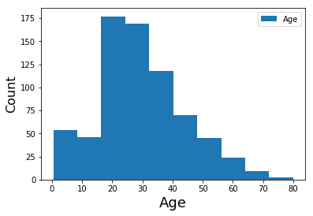

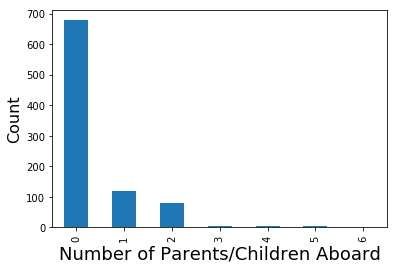

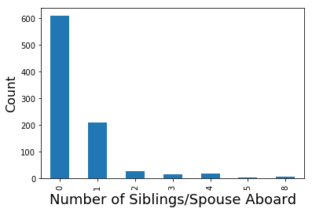

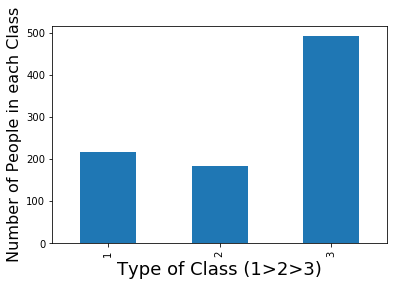

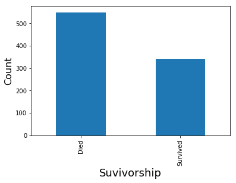

```
<function matplotlib.pyplot.close>
```

```python
# Barchart of age distrbution
data.plot(kind='hist', y = 'Age')
plt.xlabel('Age', fontsize=18)
plt.ylabel('Count', fontsize=16)
plt.show() # Most of them are young adults between the ages of 20-30 years old
plt.close


# Barchart of parents/children
parch_group.plot(kind='bar' )
plt.xlabel('Number of Parents/Children Aboard', fontsize=18)
plt.ylabel('Count', fontsize=16)
plt.show()
plt.close

# Barchart of spouse/siblings
sib_group.plot(kind='bar')
plt.xlabel('Number of Siblings/Spouse Aboard', fontsize=18)
plt.ylabel('Count', fontsize=16)
plt.show()
plt.close

# Barchart of classes
pclass_group.plot(kind = 'bar')
plt.xlabel('Type of Class (1>2>3)', fontsize=18)
plt.ylabel('Number of People in each Class', fontsize=16)
plt.show()
plt.close()

# Barchart of surviorship
survived_group.plot(kind='bar')
plt.xlabel('Suvivorship', fontsize=18)
plt.ylabel('Count', fontsize=16)
plt.xticks([0,1],['Died', 'Survived'])
plt.show()
plt.close
```

## Main Analysis

```python
#Passenger Breakdown Based on Sex.
data.groupby('Sex')['PassengerId'].count()

#Survival based on sex.
num_of_each_sex = data.groupby('Sex')['PassengerId'].count()

# Since survival is based on 1 or 0, we can easily sum them up, to conclude how many people survived.
survived_sexes = data.groupby('Sex')['Survived'].sum()
print(survived_sexes)


Percentage_of_survival_males = (survived_sexes['male'] / survived_sexes.sum()) * 100
Percentage_of_survival_females = (survived_sexes['female'] / survived_sexes.sum()) * 100
print(Percentage_of_survival_males)
print(Percentage_of_survival_females)
```

[output not shown]

Below I will figure out the survival percentage of each cabin class. I will test my hypothesis of higher class = higher survival percentage.

```
Pclass
1    216
2    184
3    491
Name: PassengerId, dtype: int64
Pclass
1    136
2     87
3    119
Name: Survived, dtype: int64
Pclass
1    62.962963
2    47.282609
3    24.236253
dtype: float64
```

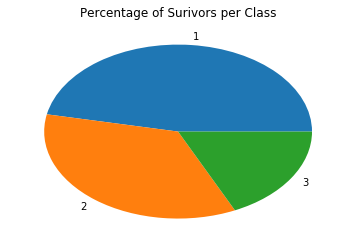

```python
#Group passengers by class
total_class= data.groupby('Pclass')['PassengerId'].count()
survived_classes = data.groupby('Pclass')['Survived'].sum()
print(total_class)
print(survived_classes)

#group survivors by class
percetage_of_survival_per_class = (survived_classes / total_class) * 100
print(percetage_of_survival_per_class)


percetage_of_survival_per_class.plot(kind='pie')
plt.title('Percentage of Surivors per Class')
plt.ylabel("")
plt.show()
```

Indeed, as I predicted, the higher the class, the higher the survivorship rate, as shown in pie graph

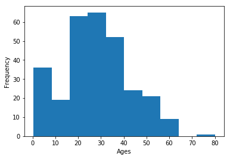

```python
survived_age_bool= dropped_age['Survived'] == 1
survived_ages = dropped_age[survived_age_bool]['Age']

survived_ages.plot(kind='hist')
plt.xlabel('Ages')
plt.show()
```

```python
#Print age survival stats
print('mean of survived ages: ' , survived_ages.mean())
print('median of survived ages: ' ,survived_ages.median())
print('miniumum of survived ages: ' ,survived_ages.min())
print('maximum of survived ages: ' ,survived_ages.max())
print('standard deviation of survived ages: ' ,survived_ages.std())
```

```
mean of survived ages:  28.343689655172415
median of survived ages:  28.0
miniumum of survived ages:  0.42
maximum of survived ages:  80.0
standard deviation of survived ages:  14.950951984140426
```

## Reviewer's suggestion:

For instance, would a male passenger in the 1st class have a higher or lower survival chance then a female passenger in the 3rd class? The groupby() method can be of help in this regard.

```python
survivorship_in_classes_by_sex =  data.groupby(['Pclass', 'Sex'])['Survived'].sum()
total_class_by_sex= data.groupby(['Pclass', 'Sex'])['PassengerId'].count()

print(survivorship_in_classes_by_sex/total_class_by_sex)
```

```
Pclass  Sex
1       female    0.968085
        male      0.368852
2       female    0.921053
        male      0.157407
3       female    0.500000
        male      0.135447
dtype: float64
```

Indeed, females had a higher survivorship in all classes

## Conclusion:

**According to my initial hypothesis.**

Findings that did not match with my initial hypothesis:

- In fact, females had a better survival rate, not males.

**Final Thoughts on the Dataset:**

There were 1,317 passengers in the titanic (http://www.titanicfacts.net/). That means there are 426 missing passengers from the dataset. Although there 177 rows missing from the age column, I do not think it affected the findings of analysis much. I was also interested in the survival rates from each cabin, that would give us an interesting insight of which parts of the ship had a higher survival rate, unfortunately, most of that column is missing (687 values).